# Coursework Report

*N* removed NAs: 2

*N* removed typo: 1

*N* removed <18: 22

*N* total clean: 125

| Group | *N* | *M*<sub>age</sub> | *M*<sub>rating</sub> |
| --- | --- | --- | --- |
| Control | 60 | 21.0 | 7.41 |
| Experim | 65 | 21.2 | 5.84 |

**Main analysis results**

*t*(123) = 12.17, *p* < .001

[interactive chart not shown]

[figure not shown]

[interactive chart not shown]

# Coursework Report

Analysing Data, Spring 2020

# Methods

## Participants

150 participants completed the experiment initially, however 25 participants were removed for ethical reasons such as being below the age of 18 or having missing data, an example being having a value of “2w” entered for age. These 125 participants had a mean age of 21.11 years, with a standard deviation of 2.08. The youngest participant was 18 and the oldest was 27.

## Design

The conceptual hypothesis for this experiment was; does colour have an effect on the attractiveness of another person.To investigate this participants were assigned to an experimental group. They were then asked to look at a picture of a woman in a frame and were asked questions about how attractive they thought she was. Colour was used as a two levelled, independent categorical variable, which was utilised through the colour of the frame which the photo of the woman was placed in. Participants in the control group saw the woman in a white frame and participants in the experimental group saw the woman in a red frame. The dependent variable was the rating each person gave over three questions about the attractiveness of the man in the photo, these questions were, “How attractive do you think this person is?”, “How pleasant is this person to look at?” and, “If I were to meet this person face to face I would think she is attractive”. This data was collected for each question as a rating of 0-9 and results were then averaged into a composite score for each participant. The rating scale worked on the basis that 0 was the lowest score possible for attractiveness and that a value of 9 indicated the highest levels of attraction.

The operational hypothesis for this experiment was whether the colour of the picture frame had an effect on the mean attractiveness rating given by participants and what the difference was between the mean composite scores of the different experimental groups. A t-test is the most appropriate way to test the hypothesis by inspecting how significant the difference is between the composite scores of the two means and whether this signifies a relationship.

# Results

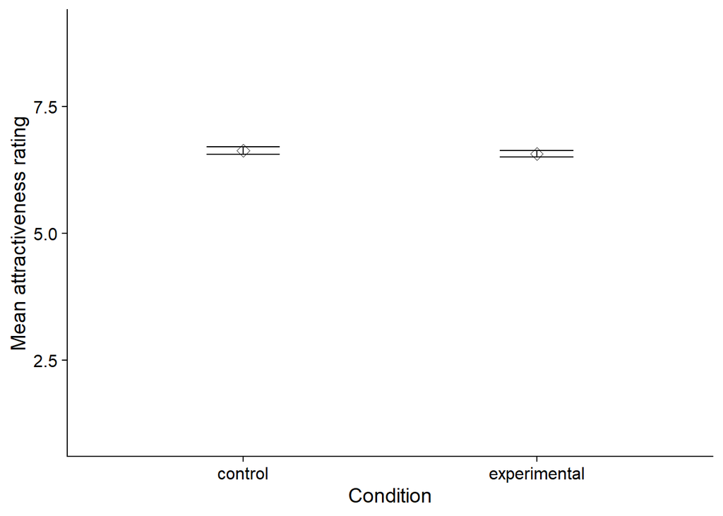

[Figure 1: Means plot showing the composite means for both experimental groups]

# Discussion

One explanation of this outcome is explained by Francis (2013) who talks about the power of the experiments conducted by Elliot et al. (2010) being under powered meaning that they used small sample sizes, meaning that the results gained were not valid, indicating that there was strong publication bias. This would explain why the results from this experiment did not follow the trend in results from the original. Elliot et al. (2010) used a sample size of 21 which is 5.95 times smaller than the sample used in this replication of experiment 1. Francis combined the power levels of the 5 experiments carried out by Elliot et al. that investigated if colour affected attractiveness and calculated it to be 2.86, this is the number of experiments out of the 5 conducted that would be expected to reject the null hypothesis, which as we know is a lot lower than the number of experiments carried out that actually rejected that null hypothesis. This would explain why the original experiments showed such a strong relationship between the colour and attractiveness. A publication bias which lies in the experimental design has seemingly led to a disproportional number of experiments rejecting the null hypothesis which compliments the hypothesis that the colour red increases how attractive a person perceives the man in the photograph to be. This is a weakness which Elliot & Maier (2013) admits in response to Francis.

However, in this response, Elliot & Maier detail a follow up experiment carried out after the criticism from Francis was written. This experiment was a replication of experiment 3 which focused on sexual, physical attraction and also focused on if red made a difference in levels of attraction when it was used in the background of the photograph. A larger sample was used of 144 women, with 75 in the experimental group and 69 in the control group, the age range was 18 – 24 with a mean age of 19.47 years. The results yielded higher levels of liking in the (red) experimental group, than the (white) control, (M = 6.29, SD = 1.35 and M = 5.93, SD = 1.49), however the difference was still not enough to be categorised as a significant difference in means.

The results gained from the data collected in this replication of Elliot et als. first experiment is similar to the data collected in a similar experiment conducted by Peperkoorn, Roberts & Pollet (2016). Their experiment consisted of 206 male participants who viewed a picture of a woman and had to rate her attractiveness. This experiment differed in that some of the participants were viewing the photo looking at the woman as a short-term mate and some were viewing the woman in the context of looking for a long-term mate. The woman was shown wearing both red and white but also black. It is worth noting that the rating was on a scale of 1-11 rather than the 1-9 scale used in the other studies looked at. The results found that there was no significant difference in whether participants were in the short-term mate or the long-term mate experimental category. The results also found that the woman in white on average was rated as more attractive than the woman wearing red or black. (White: M = 7.59, SD = 1.32 – Red: M = 7.06, SD = 1.44 – Black: M = 7.06, SD = 1.45) However these differences were not significant enough to indicate a direct relationship between the colour the woman was wearing and the average score of attractiveness.

In summary the results from this experiment and similar experiments show that there is a lot of research that is still to be done in this area. The results gained throughout these experiments show that there is no clear relationship between the colour and how attractive a person is perceived. Many of the different studies contradict each other with their results, this combined with the fact that many of the results are not significant enough to indicate a clear relationship.

A weakness of this experiment though is that participants only see one person which allows for factors like what a person defines as attractive to get in the way. Having more people for participants to rate will allow for factors like this to be prevented from affecting results. It will also mean that more diverse data will be collected because data can be collected on how colour affects the mean attractiveness of not just the colour condition but also how it affects the attractiveness of the individuals studied. This will allow for better analysis of the data and will allow for more results to be produced.

# References

Elliot, A. J., & Maier, M. A. (2013). The Red-Attractiveness Effect, Applying the Ioannidis and Trikalinos (2007b) Test, and the Broader Scientific Context: A Reply to Francis (2013). Idp.Sussex.Ac.Uk. https://search.proquest.com/docview/1285624501/fulltextPDF/C3F8FCD9F21149E6PQ/1?accountid=14182

Elliot, Andrew J., Niesta Kayser, D., Greitemeyer, T., Lichtenfeld, S., Gramzow, R. H., Maier, M. A., & Liu, H. (2010). Red, rank, and romance in women viewing men. Journal of Experimental Psychology: General, 139(3), 399–417. https://doi.org/10.1037/a0019689

Francis, G. (2013). Publication Bias in “Red, Rank, and Romance in Women Viewing Men,” by Elliot et al. (2010). Idp.Sussex.Ac.Uk. https://search.proquest.com/docview/1285624492/fulltextPDF/528114656A894F61PQ/1?accountid=14182

Peperkoorn, L. S., Roberts, S. C., & Pollet, T. V. (2016). Revisiting the Red Effect on Attractiveness and Sexual Receptivity. Evolutionary Psychology, 14(4), 147470491667384. https://doi.org/10.1177/1474704916673841